# Pokemon with stats (kaggle)- Group pokemon in groups with common characteristics

# January 2022

# Introduction

The dataset has been taken from https://www.kaggle.com/abcsds/pokemon and included the following columns: **Name**, **Type 1**, **Type 2**, **Total** : sum of the rest, **HP** : hit points, **Attack**, **Defence**, **Sp.Attk.** Special Attack, **Sp.Def** : Special Deffence, **Speed**, **Generation**,and **Legancy**

[figure not shown]

```python
import warnings
warnings.filterwarnings('ignore')
#Photo by Branden Skeli on Unsplash
from IPython import display
from PIL import Image
display.Image("pokemon.jpg")
```

# Data Importing

```python
import pandas as pd
import numpy as np

pokemon = pd.read_csv('Pokemon.csv')
pokemon
```

|  | # | Name | Type 1 | Type 2 | Total | HP | Attack | Defense | Sp. Atk | Sp. Def | Speed | Generation | Legendary |
| --- | --- | --- | --- | --- | --- | --- | --- | --- | --- | --- | --- | --- | --- |
| 0 | 1 | Bulbasaur | Grass | Poison | 318 | 45 | 49 | 49 | 65 | 65 | 45 | 1 | False |
| 1 | 2 | Ivysaur | Grass | Poison | 405 | 60 | 62 | 63 | 80 | 80 | 60 | 1 | False |
| 2 | 3 | Venusaur | Grass | Poison | 525 | 80 | 82 | 83 | 100 | 100 | 80 | 1 | False |
| 3 | 3 | VenusaurMega Venusaur | Grass | Poison | 625 | 80 | 100 | 123 | 122 | 120 | 80 | 1 | False |
| 4 | 4 | Charmander | Fire | NaN | 309 | 39 | 52 | 43 | 60 | 50 | 65 | 1 | False |
| ... | ... | ... | ... | ... | ... | ... | ... | ... | ... | ... | ... | ... | ... |
| 795 | 719 | Diancie | Rock | Fairy | 600 | 50 | 100 | 150 | 100 | 150 | 50 | 6 | True |
| 796 | 719 | DiancieMega Diancie | Rock | Fairy | 700 | 50 | 160 | 110 | 160 | 110 | 110 | 6 | True |
| 797 | 720 | HoopaHoopa Confined | Psychic | Ghost | 600 | 80 | 110 | 60 | 150 | 130 | 70 | 6 | True |
| 798 | 720 | HoopaHoopa Unbound | Psychic | Dark | 680 | 80 | 160 | 60 | 170 | 130 | 80 | 6 | True |
| 799 | 721 | Volcanion | Fire | Water | 600 | 80 | 110 | 120 | 130 | 90 | 70 | 6 | True |

800 rows × 13 columns

```python
#check for missing values, I will drop type 2 as almost half values are missing
pokemon.info()
```

```
<class 'pandas.core.frame.DataFrame'>
RangeIndex: 800 entries, 0 to 799
Data columns (total 13 columns):
 #   Column      Non-Null Count  Dtype
---  ------      --------------  -----
 0   #           800 non-null    int64
 1   Name        800 non-null    object
 2   Type 1      800 non-null    object
 3   Type 2      414 non-null    object
 4   Total       800 non-null    int64
 5   HP          800 non-null    int64
 6   Attack      800 non-null    int64
 7   Defense     800 non-null    int64
 8   Sp. Atk     800 non-null    int64
 9   Sp. Def     800 non-null    int64
 10  Speed       800 non-null    int64
 11  Generation  800 non-null    int64
 12  Legendary   800 non-null    bool
dtypes: bool(1), int64(9), object(3)
memory usage: 75.9+ KB
```

# Data Preprocessing

```python
#select only needed columns
pokemon_copy = pokemon.copy()
pokemon_copy = pokemon_copy[["Type 1","HP", "Attack", "Defense", "Sp. Atk", "Sp. Def", "Speed", "Generation", "Legendary"]]
pokemon_copy
```

|  | Type 1 | HP | Attack | Defense | Sp. Atk | Sp. Def | Speed | Generation | Legendary |
| --- | --- | --- | --- | --- | --- | --- | --- | --- | --- |
| 0 | Grass | 45 | 49 | 49 | 65 | 65 | 45 | 1 | False |
| 1 | Grass | 60 | 62 | 63 | 80 | 80 | 60 | 1 | False |
| 2 | Grass | 80 | 82 | 83 | 100 | 100 | 80 | 1 | False |
| 3 | Grass | 80 | 100 | 123 | 122 | 120 | 80 | 1 | False |
| 4 | Fire | 39 | 52 | 43 | 60 | 50 | 65 | 1 | False |
| ... | ... | ... | ... | ... | ... | ... | ... | ... | ... |
| 795 | Rock | 50 | 100 | 150 | 100 | 150 | 50 | 6 | True |
| 796 | Rock | 50 | 160 | 110 | 160 | 110 | 110 | 6 | True |
| 797 | Psychic | 80 | 110 | 60 | 150 | 130 | 70 | 6 | True |
| 798 | Psychic | 80 | 160 | 60 | 170 | 130 | 80 | 6 | True |
| 799 | Fire | 80 | 110 | 120 | 130 | 90 | 70 | 6 | True |

800 rows × 9 columns

```python
#standarize not binary columns
from sklearn.preprocessing import StandardScaler
col_names = ["HP", "Attack", "Defense", "Sp. Atk", "Sp. Def", "Speed"]
features = pokemon_copy[col_names]
scaler = StandardScaler().fit(features.values)
features = scaler.transform(features.values)

pokemon_copy[col_names] = features
#one hot encoding for type 1 and generation columns
pokemon_copy = pd.get_dummies(pokemon_copy, columns=['Type 1'], drop_first = True)
pokemon_copy = pd.get_dummies(pokemon_copy, columns=['Generation'], drop_first = True)

#replace binary columns with 1 and 0
from sklearn.preprocessing import LabelEncoder
le = LabelEncoder()
pokemon_copy["Legendary"] = le.fit_transform(pokemon_copy["Legendary"])
pokemon_copy
```

|  | HP | Attack | Defense | Sp. Atk | Sp. Def | Speed | Legendary | Type 1_Dark | Type 1_Dragon | Type 1_Electric | ... | Type 1_Poison | Type 1_Psychic | Type 1_Rock | Type 1_Steel | Type 1_Water | Generation_2 | Generation_3 | Generation_4 | Generation_5 | Generation_6 |
| --- | --- | --- | --- | --- | --- | --- | --- | --- | --- | --- | --- | --- | --- | --- | --- | --- | --- | --- | --- | --- | --- |
| 0 | -0.950626 | -0.924906 | -0.797154 | -0.239130 | -0.248189 | -0.801503 | 0 | 0 | 0 | 0 | ... | 0 | 0 | 0 | 0 | 0 | 0 | 0 | 0 | 0 | 0 |
| 1 | -0.362822 | -0.524130 | -0.347917 | 0.219560 | 0.291156 | -0.285015 | 0 | 0 | 0 | 0 | ... | 0 | 0 | 0 | 0 | 0 | 0 | 0 | 0 | 0 | 0 |
| 2 | 0.420917 | 0.092448 | 0.293849 | 0.831146 | 1.010283 | 0.403635 | 0 | 0 | 0 | 0 | ... | 0 | 0 | 0 | 0 | 0 | 0 | 0 | 0 | 0 | 0 |
| 3 | 0.420917 | 0.647369 | 1.577381 | 1.503891 | 1.729409 | 0.403635 | 0 | 0 | 0 | 0 | ... | 0 | 0 | 0 | 0 | 0 | 0 | 0 | 0 | 0 | 0 |
| 4 | -1.185748 | -0.832419 | -0.989683 | -0.392027 | -0.787533 | -0.112853 | 0 | 0 | 0 | 0 | ... | 0 | 0 | 0 | 0 | 0 | 0 | 0 | 0 | 0 | 0 |
| ... | ... | ... | ... | ... | ... | ... | ... | ... | ... | ... | ... | ... | ... | ... | ... | ... | ... | ... | ... | ... | ... |
| 795 | -0.754692 | 0.647369 | 2.443765 | 0.831146 | 2.808099 | -0.629341 | 1 | 0 | 0 | 0 | ... | 0 | 0 | 1 | 0 | 0 | 0 | 0 | 0 | 0 | 1 |
| 796 | -0.754692 | 2.497104 | 1.160233 | 2.665905 | 1.369846 | 1.436611 | 1 | 0 | 0 | 0 | ... | 0 | 0 | 1 | 0 | 0 | 0 | 0 | 0 | 0 | 1 |
| 797 | 0.420917 | 0.955658 | -0.444182 | 2.360112 | 2.088973 | 0.059310 | 1 | 0 | 0 | 0 | ... | 0 | 1 | 0 | 0 | 0 | 0 | 0 | 0 | 0 | 1 |
| 798 | 0.420917 | 2.497104 | -0.444182 | 2.971699 | 2.088973 | 0.403635 | 1 | 0 | 0 | 0 | ... | 0 | 1 | 0 | 0 | 0 | 0 | 0 | 0 | 0 | 1 |
| 799 | 0.420917 | 0.955658 | 1.481116 | 1.748526 | 0.650720 | 0.059310 | 1 | 0 | 0 | 0 | ... | 0 | 0 | 0 | 0 | 0 | 0 | 0 | 0 | 0 | 1 |

800 rows × 29 columns

# Dimension Reduction

I will use PCA for dimension reduction. I plot the PCA features variance to select the number of components to keep. I decided to keep the first 5 based on the plot below.

```python
pokemon_numpy = pokemon_copy.to_numpy()
from sklearn.decomposition import PCA
pca = PCA()
pca.fit(pokemon_numpy)
```

```
PCA()
```

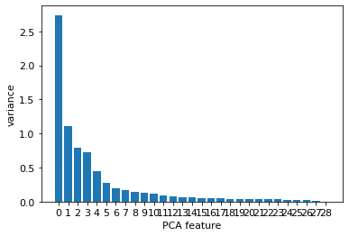

```python
features_all = range(pca.n_components_)
import matplotlib.pyplot as plt
plt.rcParams.update({'font.size': 11})
plt.bar(features_all, pca.explained_variance_)
plt.xticks(features_all)
plt.ylabel('variance')
plt.xlabel('PCA feature')
plt.show()
```

```python
pca_5 = PCA(n_components=5)
pca_5.fit(pokemon_numpy)
```

```
PCA(n_components=5)
```

```python
#transform data to 5 variables
transformed = pca_5.transform(pokemon_numpy)
print(transformed.shape)
```

```
(800, 5)
```

# Group Pokemons in Clusters

I will use Kmeans to create clusters- groups of pokemons with common characteristics

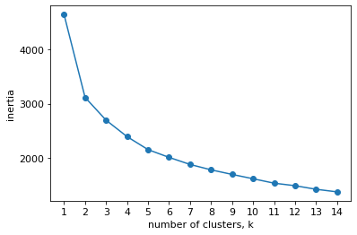

```python
from sklearn.cluster import KMeans
#find the best k
ks = range(1, 15)
inertias = []

for k in ks:
    # Create a KMeans instance with k clusters: model
    model = KMeans(n_clusters=k)

    # Fit model to samples
    model.fit(transformed)

    # Append the inertia to the list of inertias
    inertias.append(model.inertia_)

import matplotlib.pyplot as plt
# Plot ks vs inertias
plt.plot(ks, inertias, '-o')
plt.xlabel('number of clusters, k')
plt.ylabel('inertia')
plt.xticks(ks)
plt.rcParams.update({'font.size': 25})
plt.show()
```

I will select k=3. I add a column to the initial dataset with the predicted labels (groups)

```python
#create the kmeans model, fit the model
kmeans = KMeans(n_clusters=3)
kmeans.fit(transformed)

#make the predictions
labels = kmeans.predict(transformed)
```

```python
pokemon_labeled = pokemon.copy()
pokemon_labeled["cluster"] = labels
pokemon_labeled["cluster"] = pokemon_labeled["cluster"].astype("category")
pokemon_labeled
```

|  | # | Name | Type 1 | Type 2 | Total | HP | Attack | Defense | Sp. Atk | Sp. Def | Speed | Generation | Legendary | cluster |
| --- | --- | --- | --- | --- | --- | --- | --- | --- | --- | --- | --- | --- | --- | --- |
| 0 | 1 | Bulbasaur | Grass | Poison | 318 | 45 | 49 | 49 | 65 | 65 | 45 | 1 | False | 0 |
| 1 | 2 | Ivysaur | Grass | Poison | 405 | 60 | 62 | 63 | 80 | 80 | 60 | 1 | False | 0 |
| 2 | 3 | Venusaur | Grass | Poison | 525 | 80 | 82 | 83 | 100 | 100 | 80 | 1 | False | 1 |
| 3 | 3 | VenusaurMega Venusaur | Grass | Poison | 625 | 80 | 100 | 123 | 122 | 120 | 80 | 1 | False | 1 |
| 4 | 4 | Charmander | Fire | NaN | 309 | 39 | 52 | 43 | 60 | 50 | 65 | 1 | False | 0 |
| ... | ... | ... | ... | ... | ... | ... | ... | ... | ... | ... | ... | ... | ... | ... |
| 795 | 719 | Diancie | Rock | Fairy | 600 | 50 | 100 | 150 | 100 | 150 | 50 | 6 | True | 2 |
| 796 | 719 | DiancieMega Diancie | Rock | Fairy | 700 | 50 | 160 | 110 | 160 | 110 | 110 | 6 | True | 1 |
| 797 | 720 | HoopaHoopa Confined | Psychic | Ghost | 600 | 80 | 110 | 60 | 150 | 130 | 70 | 6 | True | 1 |
| 798 | 720 | HoopaHoopa Unbound | Psychic | Dark | 680 | 80 | 160 | 60 | 170 | 130 | 80 | 6 | True | 1 |
| 799 | 721 | Volcanion | Fire | Water | 600 | 80 | 110 | 120 | 130 | 90 | 70 | 6 | True | 1 |

800 rows × 14 columns

```python
#import plotting libraries/ set theme
import seaborn as sns
import matplotlib.pyplot as plt
sns.set(font_scale=1.5)
sns.set_style("whitegrid")
sns.set_palette("colorblind")
```

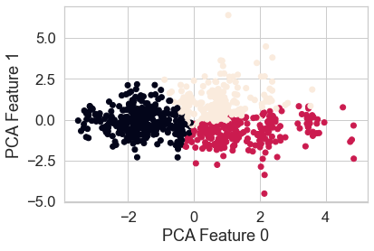

```python
#visualise the clusters
xs = transformed[:,0]
ys = transformed[:,1]
plt.scatter(xs, ys, c=labels)
plt.xlabel('PCA Feature 0')
plt.ylabel('PCA Feature 1')
plt.show()
```

# Exploratory Data Analysis

Here, I will explore the different clusters and get some summaries of the features

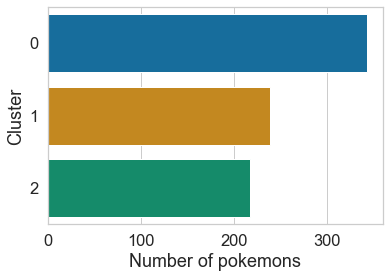

```python
sns.countplot(data=pokemon_labeled, y="cluster")
plt.xlabel('Number of pokemons')
plt.ylabel('Cluster')
```

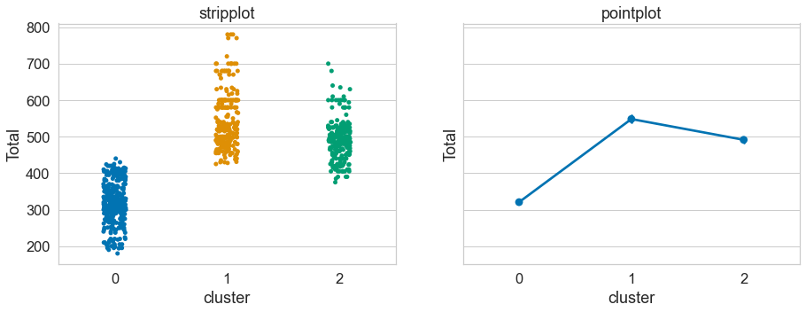

```python
fig, ax = plt.subplots(1, 2, figsize=(15, 5), sharey=True)

# stripplot
sns.stripplot(data=pokemon_labeled, x="cluster",
y="Total", ax=ax[0])
ax[0].set_title("stripplot")

# pointplot
sns.pointplot(data=pokemon_labeled, x="cluster",
y="Total", ax = ax[1])
ax[1].set_title("pointplot")
```

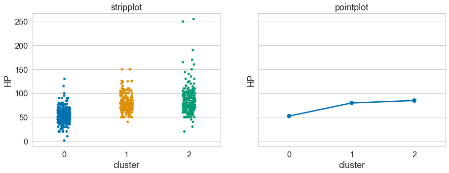

```python
fig, ax = plt.subplots(1, 2, figsize=(15, 5), sharey=True)

# stripplot
sns.stripplot(data=pokemon_labeled, x="cluster",
y="HP", ax=ax[0])
ax[0].set_title("stripplot")

# pointplot
sns.pointplot(data=pokemon_labeled, x="cluster",
y="HP", ax = ax[1])
ax[1].set_title("pointplot")
```

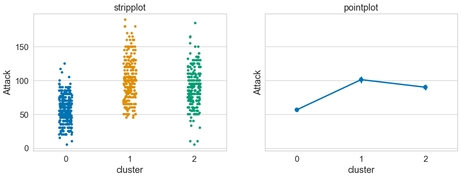

```python
fig, ax = plt.subplots(1, 2, figsize=(15, 5), sharey=True)

# stripplot
sns.stripplot(data=pokemon_labeled, x="cluster",
y="Attack", ax=ax[0])
ax[0].set_title("stripplot")

# pointplot
sns.pointplot(data=pokemon_labeled, x="cluster",
y="Attack", ax = ax[1])
ax[1].set_title("pointplot")
```

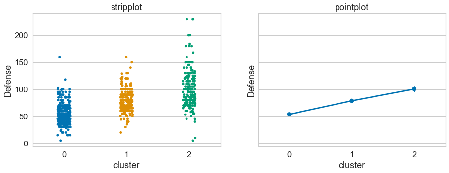

```python
fig, ax = plt.subplots(1, 2, figsize=(15, 5), sharey=True)

# stripplot
sns.stripplot(data=pokemon_labeled, x="cluster",
y="Defense", ax=ax[0])
ax[0].set_title("stripplot")

# pointplot
sns.pointplot(data=pokemon_labeled, x="cluster",
y="Defense", ax = ax[1])
ax[1].set_title("pointplot")
```

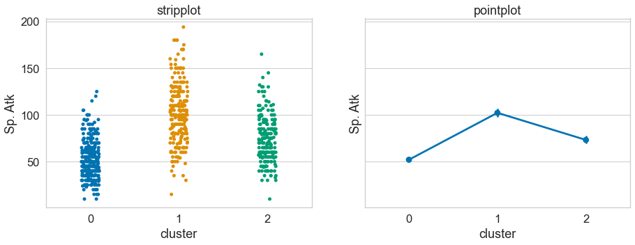

```python
fig, ax = plt.subplots(1, 2, figsize=(15, 5), sharey=True)

# stripplot
sns.stripplot(data=pokemon_labeled, x="cluster",
y="Sp. Atk", ax=ax[0])
ax[0].set_title("stripplot")

# pointplot
sns.pointplot(data=pokemon_labeled, x="cluster",
y="Sp. Atk", ax = ax[1])
ax[1].set_title("pointplot")
```

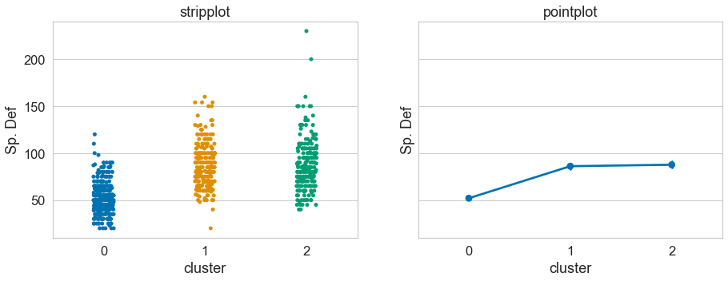

```python
fig, ax = plt.subplots(1, 2, figsize=(15, 5), sharey=True)

# stripplot
sns.stripplot(data=pokemon_labeled, x="cluster",
y="Sp. Def", ax=ax[0])
ax[0].set_title("stripplot")

# pointplot
sns.pointplot(data=pokemon_labeled, x="cluster",
y="Sp. Def", ax = ax[1])
ax[1].set_title("pointplot")
```

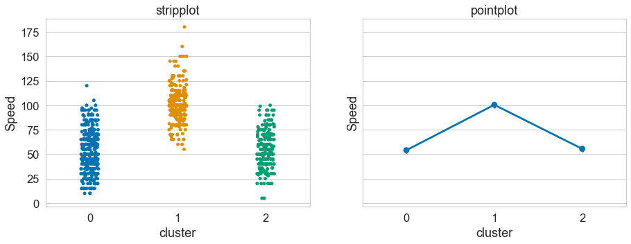

```python
fig, ax = plt.subplots(1, 2, figsize=(15, 5), sharey=True)

# stripplot
sns.stripplot(data=pokemon_labeled, x="cluster",
y="Speed", ax=ax[0])
ax[0].set_title("stripplot")

# pointplot
sns.pointplot(data=pokemon_labeled, x="cluster",
y="Speed", ax = ax[1])
ax[1].set_title("pointplot")
```

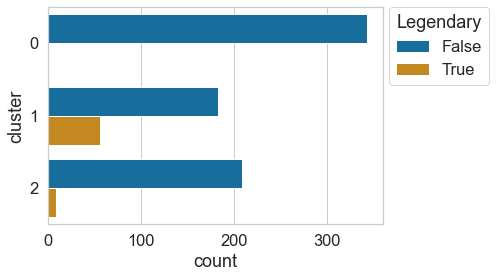

```python
sns.countplot(data=pokemon_labeled, y="cluster", hue="Legendary")
plt.legend(bbox_to_anchor=(1.02, 1), loc='upper left', borderaxespad=0, title="Legendary")
```

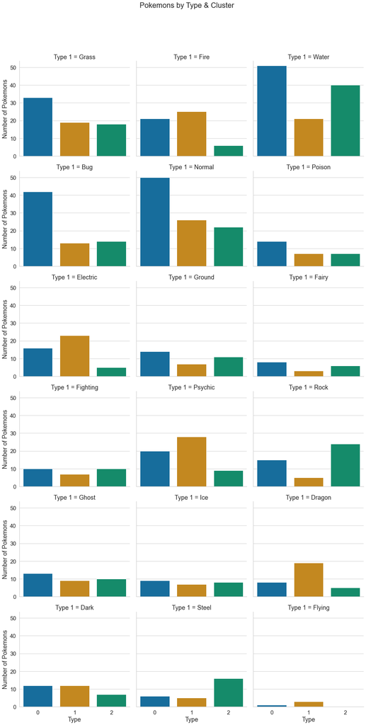

```python
ax = sns.catplot(x="cluster", col="Type 1", col_wrap=3, kind="count", data=pokemon_labeled)
ax.fig.suptitle("Pokemons by Type & Cluster")
ax.set_axis_labels("Type", "Number of Pokemons")
plt.subplots_adjust(top=.9)
plt.show()
```

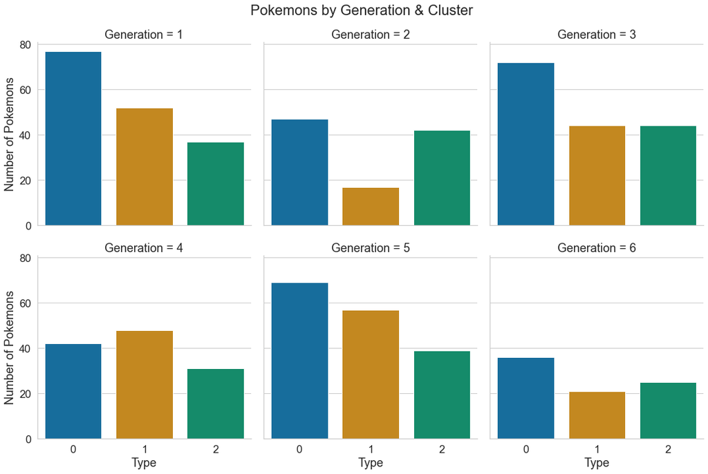

```python
ax = sns.catplot(x="cluster", col="Generation", col_wrap=3, kind="count", data=pokemon_labeled)
ax.fig.suptitle("Pokemons by Generation & Cluster")
ax.set_axis_labels("Type", "Number of Pokemons")
plt.subplots_adjust(top=.9)
plt.show()
```

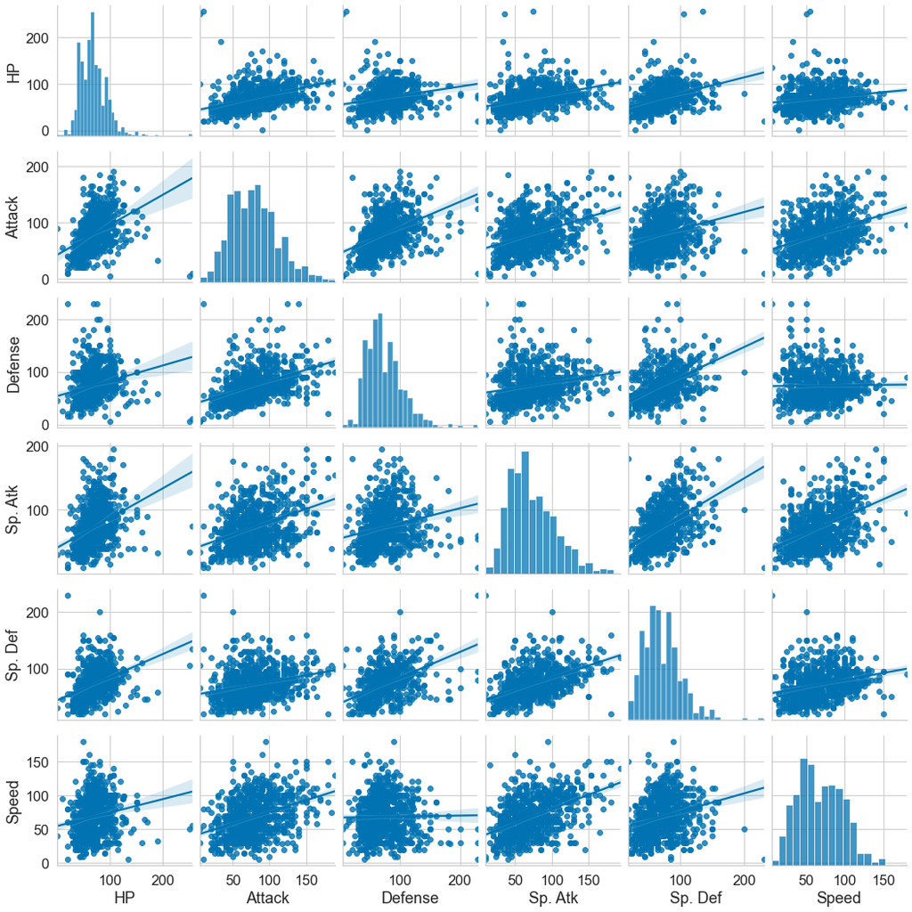

```python
num = pokemon[["HP", "Attack", "Defense", "Sp. Atk", "Sp. Def", "Speed"]]
sns.pairplot(num, kind="reg")
```

```python
s1= pokemon[["HP", "Attack", "Defense", "Sp. Atk", "Sp. Def", "Speed", "Total"]]
s1.describe()
```

|  | HP | Attack | Defense | Sp. Atk | Sp. Def | Speed | Total |
| --- | --- | --- | --- | --- | --- | --- | --- |
| count | 800.000000 | 800.000000 | 800.000000 | 800.000000 | 800.000000 | 800.000000 | 800.00000 |
| mean | 69.258750 | 79.001250 | 73.842500 | 72.820000 | 71.902500 | 68.277500 | 435.10250 |
| std | 25.534669 | 32.457366 | 31.183501 | 32.722294 | 27.828916 | 29.060474 | 119.96304 |
| min | 1.000000 | 5.000000 | 5.000000 | 10.000000 | 20.000000 | 5.000000 | 180.00000 |
| 25% | 50.000000 | 55.000000 | 50.000000 | 49.750000 | 50.000000 | 45.000000 | 330.00000 |
| 50% | 65.000000 | 75.000000 | 70.000000 | 65.000000 | 70.000000 | 65.000000 | 450.00000 |
| 75% | 80.000000 | 100.000000 | 90.000000 | 95.000000 | 90.000000 | 90.000000 | 515.00000 |
| max | 255.000000 | 190.000000 | 230.000000 | 194.000000 | 230.000000 | 180.000000 | 780.00000 |

```python
pokemon_labeled["Generation"] = pokemon_labeled["Generation"].astype("category")
s2 = pokemon_labeled[["Type 1", "Type 2", "Legendary", "cluster", "Generation"]]
s2.describe()
```

|  | Type 1 | Type 2 | Legendary | cluster | Generation |
| --- | --- | --- | --- | --- | --- |
| count | 800 | 414 | 800 | 800 | 800 |
| unique | 18 | 18 | 2 | 3 | 6 |
| top | Water | Flying | False | 0 | 1 |
| freq | 112 | 97 | 735 | 343 | 166 |

# Anomaly Detection

Finally, I want to detect possible anomalies using Local outlier factor. For this I will fit the PCA transformed 5 feature dataset

```python
from sklearn.neighbors import LocalOutlierFactor as lof
clf = lof()
y_pred_ad = clf.fit_predict(transformed)
```

```python
#create dataframe with PCA features, cluster and anomaly labels
pca_df = pd.DataFrame(transformed, columns = ["PCA feature 0", "PCA feature 1", "PCA feature 2", "PCA feature 3","PCA feature 4"])
pca_df["cluster"] = labels
pca_df["anomaly"] = y_pred_ad
pca_df
```

|  | PCA feature 0 | PCA feature 1 | PCA feature 2 | PCA feature 3 | PCA feature 4 | cluster | anomaly |
| --- | --- | --- | --- | --- | --- | --- | --- |
| 0 | -1.561808 | -0.027017 | 0.697087 | 0.178872 | 0.434653 | 0 | 1 |
| 1 | -0.374031 | -0.052211 | 0.688745 | 0.269526 | 0.254083 | 0 | 1 |
| 2 | 1.261060 | -0.059137 | 0.632494 | 0.339594 | 0.025855 | 1 | 1 |
| 3 | 2.595877 | 0.711052 | 1.005774 | -0.173637 | 0.292126 | 1 | 1 |
| 4 | -1.748536 | -0.730563 | 0.426948 | -0.292917 | 0.196138 | 0 | 1 |
| ... | ... | ... | ... | ... | ... | ... | ... |
| 795 | 2.379893 | 2.335609 | 1.963754 | -1.003936 | 0.166140 | 2 | 1 |
| 796 | 3.610627 | -0.742885 | 0.690633 | -1.880786 | 1.260577 | 1 | 1 |
| 797 | 2.543579 | -0.565788 | 1.210212 | 0.815893 | 1.178898 | 1 | 1 |
| 798 | 3.611503 | -0.985596 | 0.516894 | 0.169060 | 1.723216 | 1 | 1 |
| 799 | 2.309869 | 0.508489 | 0.306335 | -0.353991 | 1.072682 | 1 | 1 |

800 rows × 7 columns

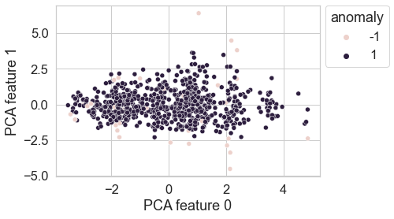

```python
#visualise the anonalies
sns.scatterplot(data=pca_df, x="PCA feature 0", y="PCA feature 1", hue="anomaly")
plt.legend(bbox_to_anchor=(1.02, 1), loc='upper left', borderaxespad=0, title = 'anomaly')
```

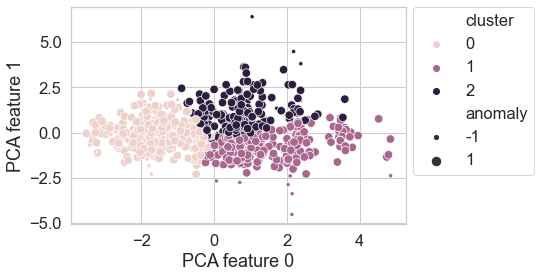

```python
#visualise cluster and anomaly
sns.scatterplot(data=pca_df, x="PCA feature 0", y="PCA feature 1", hue="cluster", size = "anomaly")
plt.legend(bbox_to_anchor=(1.02, 1), loc='upper left', borderaxespad=0)
```

# Summary

In this project, I explored a pokemon dataset and group pokemon in groups with common characteristics. Then, I explore the data and plot some summary insights. Finally, I detect possible anomalies in the dataset.